# Retired

# 1 Description of DataSchema variable

The description of harmonised variable is the following:

- Short name: `retired`
- Variable label: `Participant is currently retired`
- Variable description: `Participant is currently retired`
- Domain: `Socio-demographic and economic characteristics`
- Value type: `categorical`
- Category coding:

| **Code** | **Category Label** |
| --- | --- |
| 0 | No |
| 1 | Yes |

- Category missings:

| **Code** | **Category Label** |
| --- | --- |
| 991 | CAPI/interviewer error |
| 992 | Impute |
| 993 | Disable to measure |
| 994 | Not attempt/not done |
| 995 | Does not answer |
| 996 | Not applicable |
| 997 | Refuse |
| 998 | Do not know |
| 999 | Missing |

- Short name: `age_retired`
- Variable label: `Age (in years) at which participant retired`
- Variable description: `Respondent's age at retirement`
- Domain: `Socio-demographic and economic characteristics`
- Value type: `Continuous`
- Category missings:

| **Code** | **Category Label** |
| --- | --- |
| 991 | CAPI/interviewer error |
| 992 | Impute |
| 993 | Disable to measure |
| 994 | Not attempt/not done |
| 995 | Does not answer |
| 996 | Not applicable |
| 997 | Refuse |
| 998 | Do not know |
| 999 | Missing |

# 2 Data process

## 2.1 England

### 2.1.1 Wave 1

#### 2.1.1.1 Study-specific variable description

| **Name** | `wpdes` | `wprage` |
| --- | --- | --- |
| **Label** | `Which one of these would you say best describes your current situation?` | `You said earlier that you were (semi)retired, at what age did you retire?` |
| **Table name** | `wave_1_core_data_v3` | `wave_1_core_data_v3` |
| **Categories** | `1 = Retired` `2 = Employed` `3 = Self-employed` `4 = Unemployed` `5 = Permanently sick or disabled` `6 = Looking after home or family` `85 = Other answer - not codeable 01 to 06 or 96` `86 = Irreleva… | `continuous` |
| **Missings** | `-1 = Not applicable` `-8 = Don't Know` `-9 = Refusal` | `-1 = Not applicable` `-8 = Don't Know` `-9 = Refusal` |
| **Description** |  |  |

wpdes

| Sample size | Missing values |
| --- | --- |
| 12099 | 10 |

Category

|  | 1 | 2 | 3 | 4 | 5 | 6 | 85 | 96 |
| --- | --- | --- | --- | --- | --- | --- | --- | --- |
| Frequency | 5715.00 | 3427.00 | 696.00 | 126.00 | 790.00 | 1202.00 | 55.00 | 78.00 |
| Percentage | 47.24 | 28.32 | 5.75 | 1.04 | 6.53 | 9.93 | 0.45 | 0.64 |

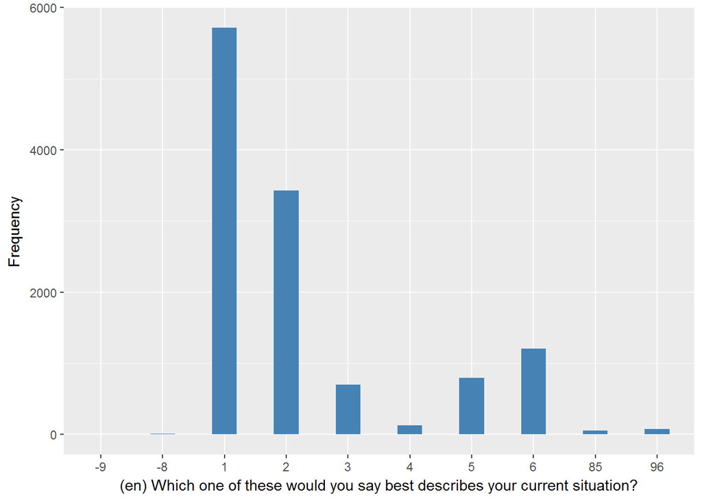

wprage

| Sample size | Missing values |
| --- | --- |
| 12099 | 6383 |

Summary

| Min. | 1st Qu. | Median | Mean | 3rd Qu. | Max. |
| --- | --- | --- | --- | --- | --- |
| 0 | 57 | 60 | 59.27 | 64 | 107 |

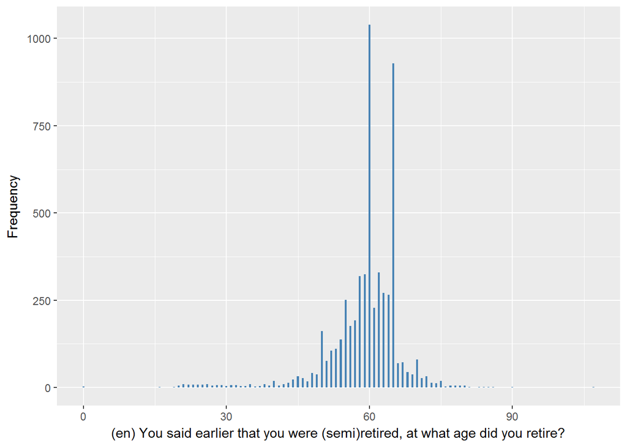

#### 2.1.1.2 Harmonisation algorithm

To compute `retired` from the study-specific variable it has to be recoded as follows:

- `1,96 into 1`
- `2,3,4,5,6,85,86,95 into 0`
- `-1 into 996`
- `-8 into 998`
- `-9 into 997`

To compute `age_retired` from the study-specific variable it has to be recoded as follows:

- `if retired == 1, age_retired = wprage`
- `-1 into 996`
- `-8 into 998`
- `-9 into 997`
- `if retired == 0, age_retired = 996`

**R script:**

```r
# Categorical variable harmonization
ELSA_ds_w1 <- tibble(id = ELSA_w1$id)
ELSA_ds_w1$retired <- car::recode(ELSA_w1$wpdes, "c(1,96) = 1; c(2,3,4,5,6,85,86,95) = 0; -1 = 996; -8 = 998; -9 = 997")

# Continuous variable harmonization
ELSA_ds_w1$age_retired <- car::recode(ELSA_w1$wprage, "c(-1,0) = 996; -8 = 998; -9 = 997; NA = 999")
ELSA_ds_w1$age_retired[which(ELSA_ds_w1$retired == 0)] <- 996

# Correction of the age of retirement of individuals 112305 and 119579,
# which in wave 1 answer 0 and 107 and have 83 and 74 years old, while in
# waves 4 and 6 answer 55 and 50 respectively.
ELSA_ds_w1$age_retired[which(ELSA_ds_w1$id == "112305")] <- 55
ELSA_ds_w1$age_retired[which(ELSA_ds_w1$id == "119579")] <- 50

# Global table
ELSA_ds <- ELSA_ds_w1
```

#### 2.1.1.3 Statistics of the new harmonized variable

Participant is currently retired

| Sample size | Missing values |
| --- | --- |
| 12099 | 10 |

Category

|  | 0 | 1 |
| --- | --- | --- |
| Frequency | 6296.00 | 5793.00 |
| Percentage | 52.04 | 47.88 |

Type of missing

|  | 991 | 992 | 993 | 994 | 995 | 996 | 997 | 998 | 999 | NA |
| --- | --- | --- | --- | --- | --- | --- | --- | --- | --- | --- |
| Frequency | 0 | 0 | 0 | 0 | 0 | 0 | 4.00 | 6.00 | 0 | 0 |
| Percentage | 0 | 0 | 0 | 0 | 0 | 0 | 0.03 | 0.05 | 0 | 0 |

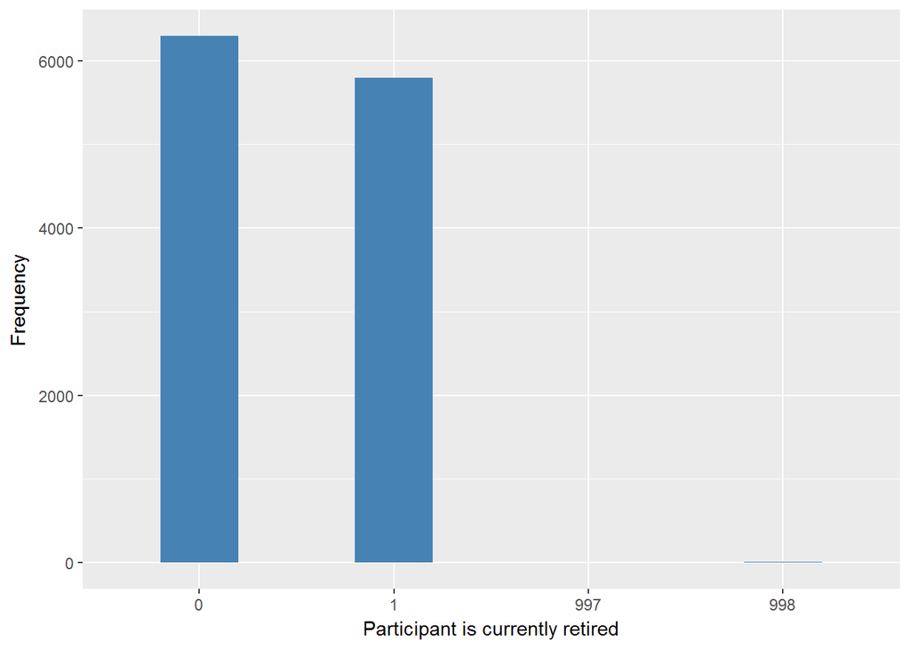

Age (in years) at which participant retired

| Sample size | Missing values |
| --- | --- |
| 12099 | 6385 |

Values

|  | No-missings | 991 | 992 | 993 | 994 | 995 | 996 | 997 | 998 | 999 | NA |
| --- | --- | --- | --- | --- | --- | --- | --- | --- | --- | --- | --- |
| Frequency | 5714.00 | 0 | 0 | 0 | 0 | 0 | 6318.00 | 13.00 | 54.00 | 0 | 0 |
| Percentage | 47.23 | 0 | 0 | 0 | 0 | 0 | 52.22 | 0.11 | 0.45 | 0 | 0 |

Summary

| Min. | 1st Qu. | Median | Mean | 3rd Qu. | Max. |
| --- | --- | --- | --- | --- | --- |
| 16 | 57 | 60 | 59.29 | 64 | 90 |

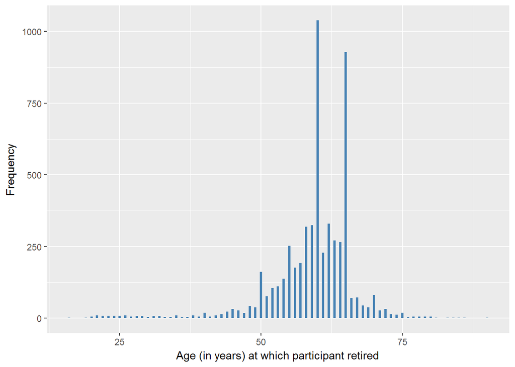

#### 2.1.1.4 Validation

### 2.1.2 Wave 2

#### 2.1.2.1 Study-specific variable description

| **Name** | `wpdes` | `wprage` |
| --- | --- | --- |
| **Label** | `Best description of current situation` | `You said earlier that you were (semi)retired, at what age did you retire?` |
| **Table name** | `wave_2_core_data_v4` | `wave_2_core_data_v4` |
| **Categories** | `1 = Retired` `2 = Employed` `3 = Self-employed` `4 = Unemployed` `5 = Permanently sick or disabled` `6 = Looking after home or family` `85 = Other answer - not codeable 01 to 06 or 96` `86 = Irreleva… | `continuous` |
| **Missings** | `-1 = Not applicable` `-8 = Don't Know` `-9 = Refusal` | `-1 = Not applicable` `-8 = Don't Know` `-9 = Refusal` |
| **Description** |  |  |

wpdes

| Sample size | Missing values |
| --- | --- |
| 9432 | 2 |

Category

|  | 1 | 2 | 3 | 4 | 5 | 6 | 85 | 96 |
| --- | --- | --- | --- | --- | --- | --- | --- | --- |
| Frequency | 4775.00 | 2452 | 524.00 | 75.0 | 539.00 | 986.00 | 30.00 | 49.00 |
| Percentage | 50.63 | 26 | 5.56 | 0.8 | 5.71 | 10.45 | 0.32 | 0.52 |

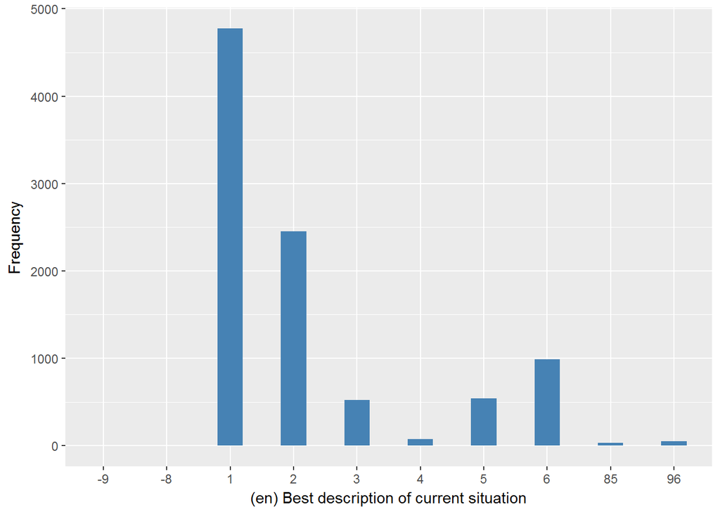

wprage

| Sample size | Missing values |
| --- | --- |
| 9432 | 8438 |

Summary

| Min. | 1st Qu. | Median | Mean | 3rd Qu. | Max. |
| --- | --- | --- | --- | --- | --- |
| 0 | 55 | 60 | 57.43 | 63 | 78 |

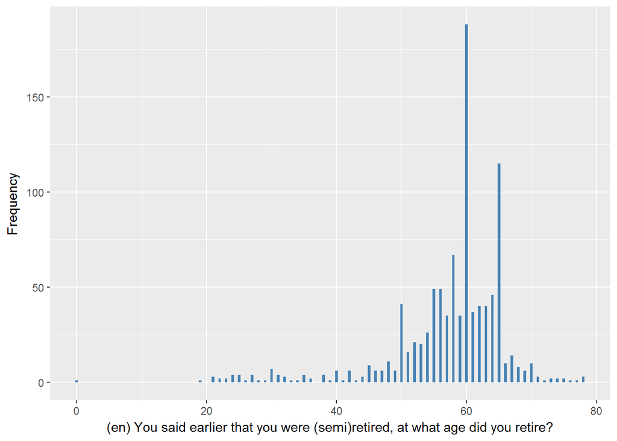

#### 2.1.2.2 Harmonisation algorithm

To compute `retired` from the study-specific variable it has to be recoded as follows:

- `1,96 into 1`
- `2,3,4,5,6,85,86,95 into 0`
- `-1 into 996`
- `-8 into 998`
- `-9 into 997`

To compute `age_retired` from the study-specific variable it has to be recoded as follows:

- `if retired == 1, age_retired = wprage`
- `-1 into 996`
- `-8 into 998`
- `-9 into 997`
- `if retired == 0, age_retired = 996`

**R script:**

```r
# Categorical variable harmonization
ELSA_ds_w2 <- tibble(id = ELSA_w2$id)
ELSA_ds_w2$retired <- car::recode(ELSA_w2$wpdes, "c(1,96) = 1; c(2,3,4,5,6,85,86,95) = 0; -1 = 996; -8 = 998; -9 = 997")

ELSA_w2 <- left_join(ELSA_w2, ELSA_ds, by = "id")

# Continuous variable harmonization
ELSA_ds_w2$age_retired <- car::recode(ELSA_w2$wprage, "c(-1,0) = 996; -8 = 998; -9 = 997; NA = 999")
ELSA_ds_w2$age_retired[which(!is.na(ELSA_w2$age_retired) & !ELSA_w2$age_retired %in%
    miss_values_vector)] <- ELSA_w2$age_retired[which(!is.na(ELSA_w2$age_retired) &
    !ELSA_w2$age_retired %in% miss_values_vector)]
ELSA_ds_w2$age_retired[which(!ELSA_w2$wprage %in% c(-1, 0, -8, -9))] <- ELSA_w2$wprage[which(!ELSA_w2$wprage %in%
    c(-1, 0, -8, -9))]

# Update of global table
assign_merge <- function(endtib, sttib, log_vec = c(T), col_end_index = NULL,
    col_st_index = NULL) {
    newtib <- full_join(endtib, sttib, by = "id")
    row.names(newtib) <- newtib$id
    newtib[log_vec, col_end_index] <- newtib[log_vec, col_st_index]
    id_ind <- match("id", names(newtib))
    newtib <- newtib[, c(id_ind, col_end_index)]
    names(newtib)[2] <- "x"
    newtib$x <- car::recode(newtib$x, "NA=999")
    names(newtib)[2] <- names(endtib)[col_end_index]
    newtib
}
ELSA_ds_prov <- ELSA_ds[, c(1, 2)]
ELSA_ds_prov <- assign_merge(ELSA_ds_prov, ELSA_ds_w2, log_vec = ELSA_ds_w2$id,
    col_end_index = 2, col_st_index = 3)
ELSA_ds_aux <- ELSA_ds[, c(1, 3)]
ELSA_ds_aux <- assign_merge(ELSA_ds_aux, ELSA_ds_w2, log_vec = ELSA_ds_w2$id[which(ELSA_ds_w2$retired !=
    999)], col_end_index = 2, col_st_index = 4)
ELSA_ds <- ELSA_ds_prov
ELSA_ds$age_retired <- ELSA_ds_aux$age_retired
rm(ELSA_ds_prov)
rm(ELSA_ds_aux)
```

#### 2.1.2.3 Statistics of the new harmonized variable

Participant is currently retired

| Sample size | Missing values |
| --- | --- |
| 9432 | 2 |

Category

|  | 0 | 1 |
| --- | --- | --- |
| Frequency | 4606.00 | 4824.00 |
| Percentage | 48.83 | 51.15 |

Type of missing

|  | 991 | 992 | 993 | 994 | 995 | 996 | 997 | 998 | 999 | NA |
| --- | --- | --- | --- | --- | --- | --- | --- | --- | --- | --- |
| Frequency | 0 | 0 | 0 | 0 | 0 | 0 | 1.00 | 1.00 | 0 | 0 |
| Percentage | 0 | 0 | 0 | 0 | 0 | 0 | 0.01 | 0.01 | 0 | 0 |

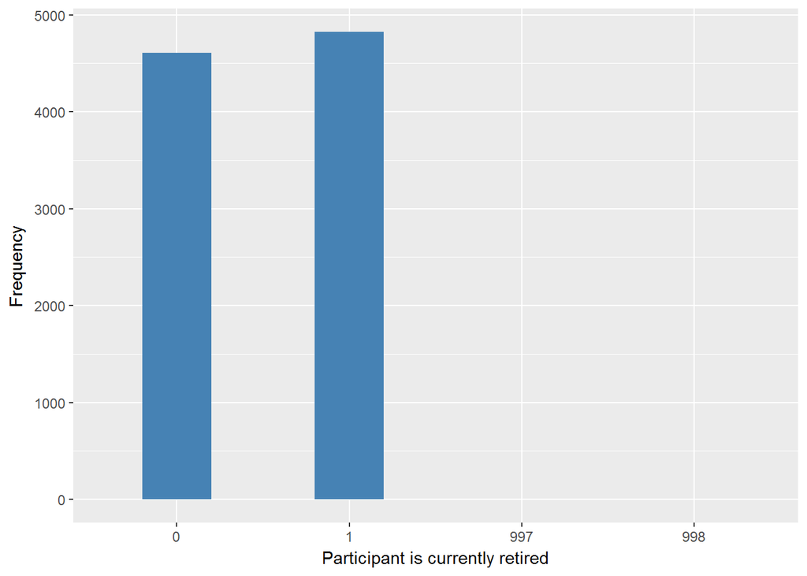

Age (in years) at which participant retired

| Sample size | Missing values |
| --- | --- |
| 9432 | 4090 |

Values

|  | No-missings | 991 | 992 | 993 | 994 | 995 | 996 | 997 | 998 | 999 | NA |
| --- | --- | --- | --- | --- | --- | --- | --- | --- | --- | --- | --- |
| Frequency | 5342.00 | 0 | 0 | 0 | 0 | 0 | 4065.0 | 8.00 | 17.00 | 0 | 0 |
| Percentage | 56.64 | 0 | 0 | 0 | 0 | 0 | 43.1 | 0.08 | 0.18 | 0 | 0 |

Summary

| Min. | 1st Qu. | Median | Mean | 3rd Qu. | Max. |
| --- | --- | --- | --- | --- | --- |
| 19 | 56 | 60 | 58.86 | 64 | 86 |

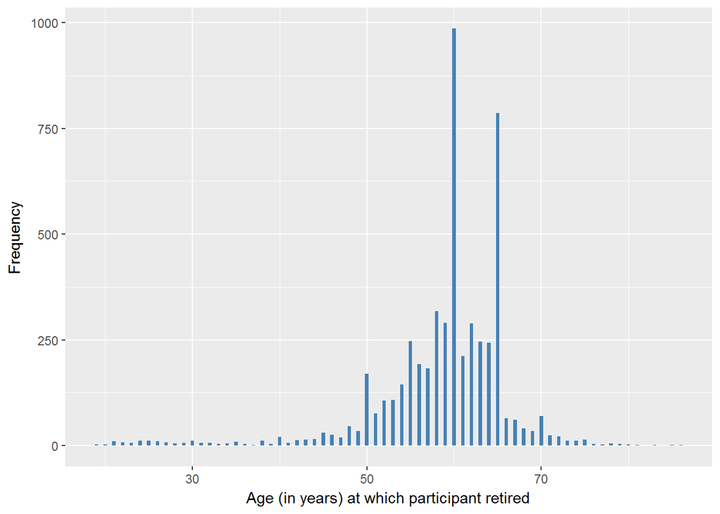

#### 2.1.2.4 Validation

### 2.1.3 Wave 3

#### 2.1.3.1 Study-specific variable description

| **Name** | `wpdes` | `wprage` |
| --- | --- | --- |
| **Label** | `Best description of current situation` | `You said earlier that you were (semi)retired, at what age did you retire?` |
| **Table name** | `wave_3_elsa_data_v4` | `wave_3_elsa_data_v4` |
| **Categories** | `1 = Retired` `2 = Employed` `3 = Self-employed` `4 = Unemployed` `5 = Permanently sick or disabled` `6 = Looking after home or family` `95 = Other (SPECIFY)` `96 = SPONTANEOUS : Semi-retired` | `continuous` |
| **Missings** | `-1 = Not applicable` `-8 = Don't Know` `-9 = Refusal` | `-1 = Not applicable` `-8 = Don't Know` `-9 = Refusal` |
| **Description** |  |  |

wpdes

| Sample size | Missing values |
| --- | --- |
| 9771 | 4 |

Category

|  | 1 | 2 | 3 | 4 | 5 | 6 | 95 | 96 |
| --- | --- | --- | --- | --- | --- | --- | --- | --- |
| Frequency | 4580.00 | 3065.00 | 623.00 | 85.00 | 539.00 | 816.00 | 22.00 | 37.00 |
| Percentage | 46.87 | 31.37 | 6.38 | 0.87 | 5.52 | 8.35 | 0.23 | 0.38 |

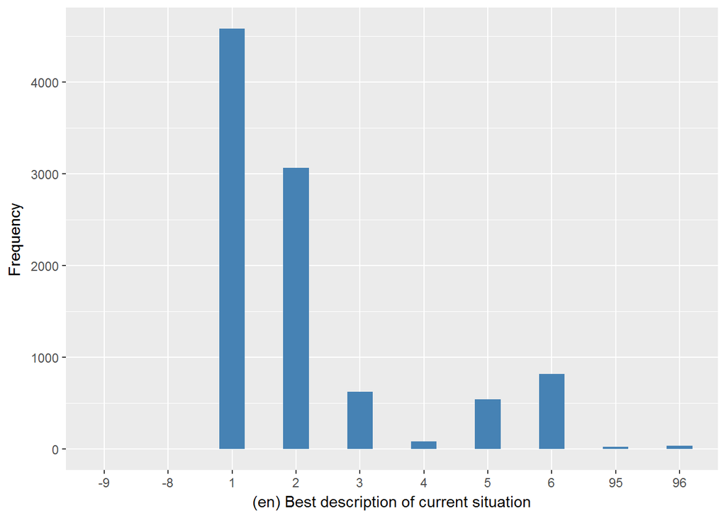

wprage

| Sample size | Missing values |
| --- | --- |
| 9771 | 9085 |

Summary

| Min. | 1st Qu. | Median | Mean | 3rd Qu. | Max. |
| --- | --- | --- | --- | --- | --- |
| 0 | 54 | 60 | 57.14 | 62.75 | 86 |

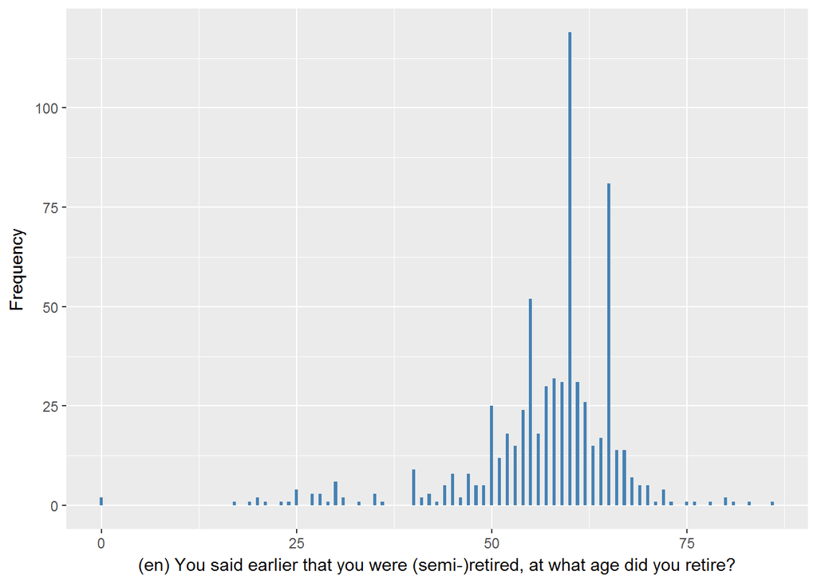

#### 2.1.3.2 Harmonisation algorithm

To compute `retired` from the study-specific variable it has to be recoded as follows:

- `1,96 into 1`
- `2,3,4,5,6,95 into 0`
- `-1 into 996`
- `-8 into 998`
- `-9 into 997`

To compute `age_retired` from the study-specific variable it has to be recoded as follows:

- `if retired == 1, age_retired = wprage`
- `-1 into 996`
- `-8 into 998`
- `-9 into 997`
- `if retired == 0, age_retired = 996`

**R script:**

```r
# Categorical variable harmonization
ELSA_ds_w3 <- tibble(id = ELSA_w3$id)
ELSA_ds_w3$retired <- car::recode(ELSA_w3$wpdes, "c(1,96) = 1; c(2,3,4,5,6,95) = 0; -1 = 996; -8 = 998; -9 = 997")

ELSA_w3 <- left_join(ELSA_w3, ELSA_ds, by = "id")

# Continuous variable harmonization
ELSA_ds_w3$age_retired <- car::recode(ELSA_w3$wprage, "c(-1,0) = 996; -8 = 998; -9 = 997; NA = 999")
ELSA_ds_w3$age_retired[which(!is.na(ELSA_w3$age_retired) & !ELSA_w3$age_retired %in%
    miss_values_vector)] <- ELSA_w3$age_retired[which(!is.na(ELSA_w3$age_retired) &
    !ELSA_w3$age_retired %in% miss_values_vector)]
ELSA_ds_w3$age_retired[which(!ELSA_w3$wprage %in% c(-1, 0, -8, -9))] <- ELSA_w3$wprage[which(!ELSA_w3$wprage %in%
    c(-1, 0, -8, -9))]

# Update of global table
assign_merge <- function(endtib, sttib, log_vec = c(T), col_end_index = NULL,
    col_st_index = NULL) {
    newtib <- full_join(endtib, sttib, by = "id")
    row.names(newtib) <- newtib$id
    newtib[log_vec, col_end_index] <- newtib[log_vec, col_st_index]
    id_ind <- match("id", names(newtib))
    newtib <- newtib[, c(id_ind, col_end_index)]
    names(newtib)[2] <- "x"
    newtib$x <- car::recode(newtib$x, "NA=999")
    names(newtib)[2] <- names(endtib)[col_end_index]
    newtib
}
ELSA_ds_prov <- ELSA_ds[, c(1, 2)]
ELSA_ds_prov <- assign_merge(ELSA_ds_prov, ELSA_ds_w3, log_vec = ELSA_ds_w3$id,
    col_end_index = 2, col_st_index = 3)
ELSA_ds_aux <- ELSA_ds[, c(1, 3)]
ELSA_ds_aux <- assign_merge(ELSA_ds_aux, ELSA_ds_w3, log_vec = ELSA_ds_w3$id[which(ELSA_ds_w3$retired !=
    999)], col_end_index = 2, col_st_index = 4)
ELSA_ds <- ELSA_ds_prov
ELSA_ds$age_retired <- ELSA_ds_aux$age_retired
rm(ELSA_ds_prov)
rm(ELSA_ds_aux)
```

#### 2.1.3.3 Statistics of the new harmonized variable

Participant is currently retired

| Sample size | Missing values |
| --- | --- |
| 9771 | 4 |

Category

|  | 0 | 1 |
| --- | --- | --- |
| Frequency | 5150.00 | 4617.00 |
| Percentage | 52.71 | 47.25 |

Type of missing

|  | 991 | 992 | 993 | 994 | 995 | 996 | 997 | 998 | 999 | NA |
| --- | --- | --- | --- | --- | --- | --- | --- | --- | --- | --- |
| Frequency | 0 | 0 | 0 | 0 | 0 | 0 | 2.00 | 2.00 | 0 | 0 |
| Percentage | 0 | 0 | 0 | 0 | 0 | 0 | 0.02 | 0.02 | 0 | 0 |

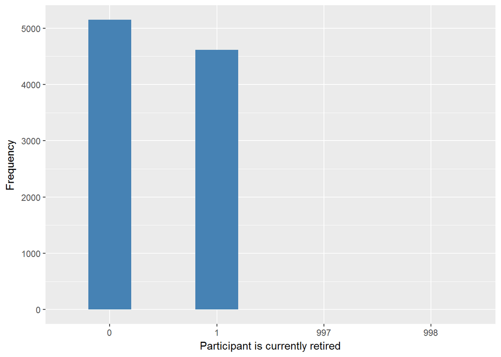

Age (in years) at which participant retired

| Sample size | Missing values |
| --- | --- |
| 9771 | 4649 |

Values

|  | No-missings | 991 | 992 | 993 | 994 | 995 | 996 | 997 | 998 | 999 | NA |
| --- | --- | --- | --- | --- | --- | --- | --- | --- | --- | --- | --- |
| Frequency | 5122.00 | 0 | 0 | 0 | 0 | 0 | 4624.00 | 2.00 | 23.00 | 0 | 0 |
| Percentage | 52.42 | 0 | 0 | 0 | 0 | 0 | 47.32 | 0.02 | 0.24 | 0 | 0 |

Summary

| Min. | 1st Qu. | Median | Mean | 3rd Qu. | Max. |
| --- | --- | --- | --- | --- | --- |
| 17 | 56 | 60 | 58.67 | 64 | 86 |

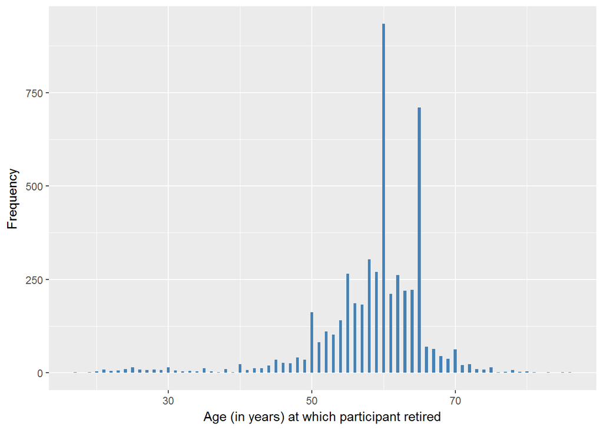

#### 2.1.3.4 Validation

### 2.1.4 Wave 4

#### 2.1.4.1 Study-specific variable description

| **Name** | `wpdes` | `wprage` |
| --- | --- | --- |
| **Label** | `Best description of current situation` | `You said earlier that you were (semi)retired, at what age did you retire?` |
| **Table name** | `wave_4_elsa_data_v3` | `wave_4_elsa_data_v3` |
| **Categories** | `1 = Retired` `2 = Employed` `3 = Self-employed` `4 = Unemployed` `5 = Permanently sick or disabled` `6 = Looking after home or family` `85 = Other answer - not codeable` `86 = Code86` `95 = Other` `9… | `continuous` |
| **Missings** | `-1 = Not applicable` `-2 = CAPI/Interview error` `-8 = Don't Know` `-9 = Refusal` | `-1 = Not applicable` `-2 = CAPI/Interview error` `-8 = Don't Know` `-9 = Refusal` |
| **Description** |  |  |

wpdes

| Sample size | Missing values |
| --- | --- |
| 11050 | 12 |

Category

|  | 1 | 2 | 3 | 4 | 5 | 6 | 85 | 95 | 96 |
| --- | --- | --- | --- | --- | --- | --- | --- | --- | --- |
| Frequency | 5543.00 | 3253.00 | 733.00 | 132.00 | 592.00 | 722.00 | 1.00 | 1.00 | 61.00 |
| Percentage | 50.16 | 29.44 | 6.63 | 1.19 | 5.36 | 6.53 | 0.01 | 0.01 | 0.55 |

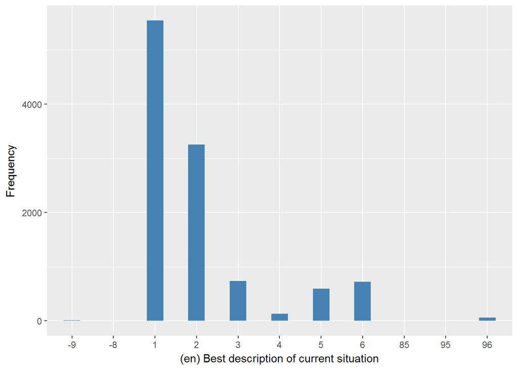

wprage

| Sample size | Missing values |
| --- | --- |
| 11050 | 9382 |

Summary

| Min. | 1st Qu. | Median | Mean | 3rd Qu. | Max. |
| --- | --- | --- | --- | --- | --- |
| 20 | 56 | 60 | 58.65 | 63 | 75 |

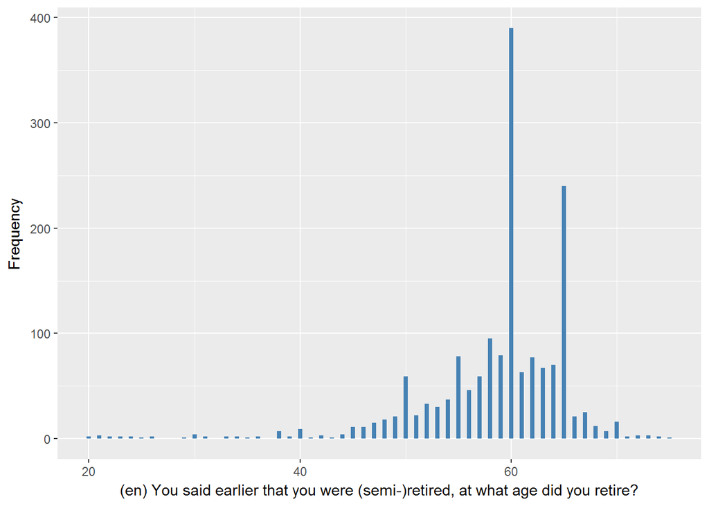

#### 2.1.4.2 Harmonisation algorithm

To compute `retired` from the study-specific variable it has to be recoded as follows:

- `1,96 into 1`
- `2,3,4,5,6,85,86,95 into 0`
- `-1 into 996`
- `-2 into 991`
- `-8 into 998`
- `-9 into 997`

To compute `age_retired` from the study-specific variable it has to be recoded as follows:

- `if retired == 1, age_retired = wprage`
- `-1 into 996`
- `-2 into 991`
- `-8 into 998`
- `-9 into 997`
- `if retired == 0, age_retired = 996`

**R script:**

```r
# Categorical variable harmonization
ELSA_ds_w4 <- tibble(id = ELSA_w4$id)
ELSA_ds_w4$retired <- car::recode(ELSA_w4$wpdes, "c(1,96) = 1; c(2,3,4,5,6,85,86,95) = 0; -1 = 996; -2 = 991; -8 = 998; -9 = 997")

ELSA_w4 <- left_join(ELSA_w4, ELSA_ds, by = "id")

# Continuous variable harmonization
ELSA_ds_w4$age_retired <- car::recode(ELSA_w4$wprage, "c(-1,0) = 996; -2 = 991; -8 = 998; -9 = 997; NA = 999")
ELSA_ds_w4$age_retired[which(!is.na(ELSA_w4$age_retired) & !ELSA_w4$age_retired %in%
    miss_values_vector)] <- ELSA_w4$age_retired[which(!is.na(ELSA_w4$age_retired) &
    !ELSA_w4$age_retired %in% miss_values_vector)]
ELSA_ds_w4$age_retired[which(!ELSA_w4$wprage %in% c(-2, -1, 0, -8, -9))] <- ELSA_w4$wprage[which(!ELSA_w4$wprage %in%
    c(-2, -1, 0, -8, -9))]

# Update of global table
assign_merge <- function(endtib, sttib, log_vec = c(T), col_end_index = NULL,
    col_st_index = NULL) {
    newtib <- full_join(endtib, sttib, by = "id")
    row.names(newtib) <- newtib$id
    newtib[log_vec, col_end_index] <- newtib[log_vec, col_st_index]
    id_ind <- match("id", names(newtib))
    newtib <- newtib[, c(id_ind, col_end_index)]
    names(newtib)[2] <- "x"
    newtib$x <- car::recode(newtib$x, "NA=999")
    names(newtib)[2] <- names(endtib)[col_end_index]
    newtib
}
ELSA_ds_prov <- ELSA_ds[, c(1, 2)]
ELSA_ds_prov <- assign_merge(ELSA_ds_prov, ELSA_ds_w4, log_vec = ELSA_ds_w4$id,
    col_end_index = 2, col_st_index = 3)
ELSA_ds_aux <- ELSA_ds[, c(1, 3)]
ELSA_ds_aux <- assign_merge(ELSA_ds_aux, ELSA_ds_w4, log_vec = ELSA_ds_w4$id[which(ELSA_ds_w4$retired !=
    999)], col_end_index = 2, col_st_index = 4)
ELSA_ds <- ELSA_ds_prov
ELSA_ds$age_retired <- ELSA_ds_aux$age_retired
rm(ELSA_ds_prov)
rm(ELSA_ds_aux)
```

#### 2.1.4.3 Statistics of the new harmonized variable

Participant is currently retired

| Sample size | Missing values |
| --- | --- |
| 11050 | 12 |

Category

|  | 0 | 1 |
| --- | --- | --- |
| Frequency | 5434.00 | 5604.00 |
| Percentage | 49.18 | 50.71 |

Type of missing

|  | 991 | 992 | 993 | 994 | 995 | 996 | 997 | 998 | 999 | NA |
| --- | --- | --- | --- | --- | --- | --- | --- | --- | --- | --- |
| Frequency | 0 | 0 | 0 | 0 | 0 | 0 | 8.00 | 4.00 | 0 | 0 |
| Percentage | 0 | 0 | 0 | 0 | 0 | 0 | 0.07 | 0.04 | 0 | 0 |

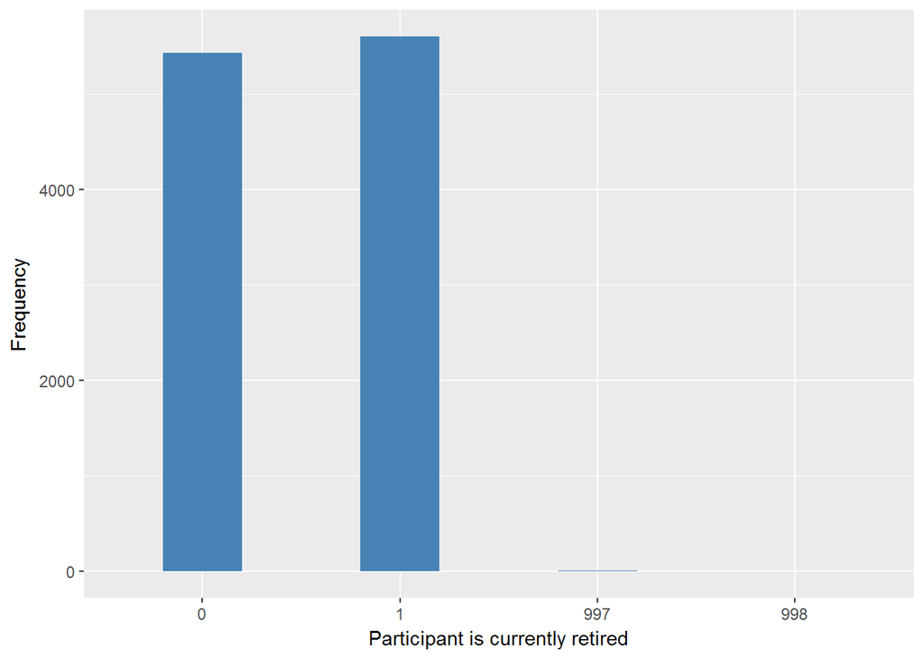

Age (in years) at which participant retired

| Sample size | Missing values |
| --- | --- |
| 11050 | 5016 |

Values

|  | No-missings | 991 | 992 | 993 | 994 | 995 | 996 | 997 | 998 | 999 | NA |
| --- | --- | --- | --- | --- | --- | --- | --- | --- | --- | --- | --- |
| Frequency | 6034.00 | 28.00 | 0 | 0 | 0 | 0 | 4958.00 | 3.00 | 27.00 | 0 | 0 |
| Percentage | 54.61 | 0.25 | 0 | 0 | 0 | 0 | 44.87 | 0.03 | 0.24 | 0 | 0 |

Summary

| Min. | 1st Qu. | Median | Mean | 3rd Qu. | Max. |
| --- | --- | --- | --- | --- | --- |
| 17 | 56 | 60 | 58.56 | 63 | 86 |

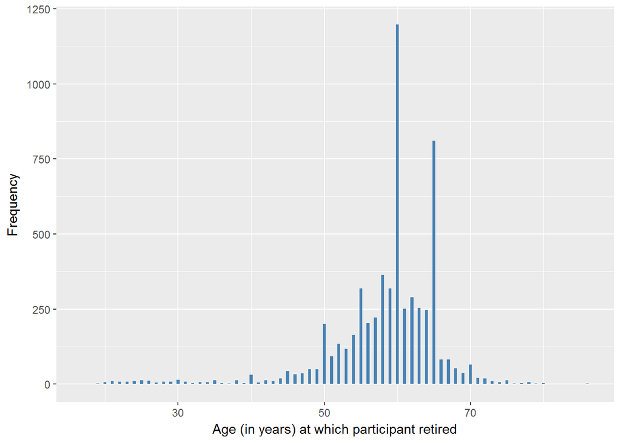

#### 2.1.4.4 Validation

### 2.1.5 Wave 5

#### 2.1.5.1 Study-specific variable description

| **Name** | `wpdes` | `wprage` |
| --- | --- | --- |
| **Label** | `Best description of current situation` | `You said earlier that you were (semi)retired, at what age did you retire?` |
| **Table name** | `wave_5_elsa_data_v4` | `wave_5_elsa_data_v4` |
| **Categories** | `1 = Retired` `2 = Employed` `3 = Self-employed` `4 = Unemployed` `5 = Permanently sick or disabled` `6 = Looking after home or family` `85 = Other answer` `86 = Irrelevant response` `95 = Other (SPEC… | `continuous` |
| **Missings** | `-1 = Not applicable` `-2 = Schedule not applicable` `-8 = Don't Know` `-9 = Refusal` | `-1 = Not applicable` `-2 = Schedule not applicable` `-8 = Don't Know` `-9 = Refusal` |
| **Description** |  |  |

wpdes

| Sample size | Missing values |
| --- | --- |
| 10274 | 8 |

Category

|  | 1 | 2 | 3 | 4 | 5 | 6 | 85 | 86 | 96 |
| --- | --- | --- | --- | --- | --- | --- | --- | --- | --- |
| Frequency | 5676.00 | 2613.00 | 646.00 | 114.00 | 515.00 | 612.00 | 31.0 | 2.00 | 57.00 |
| Percentage | 55.25 | 25.43 | 6.29 | 1.11 | 5.01 | 5.96 | 0.3 | 0.02 | 0.55 |

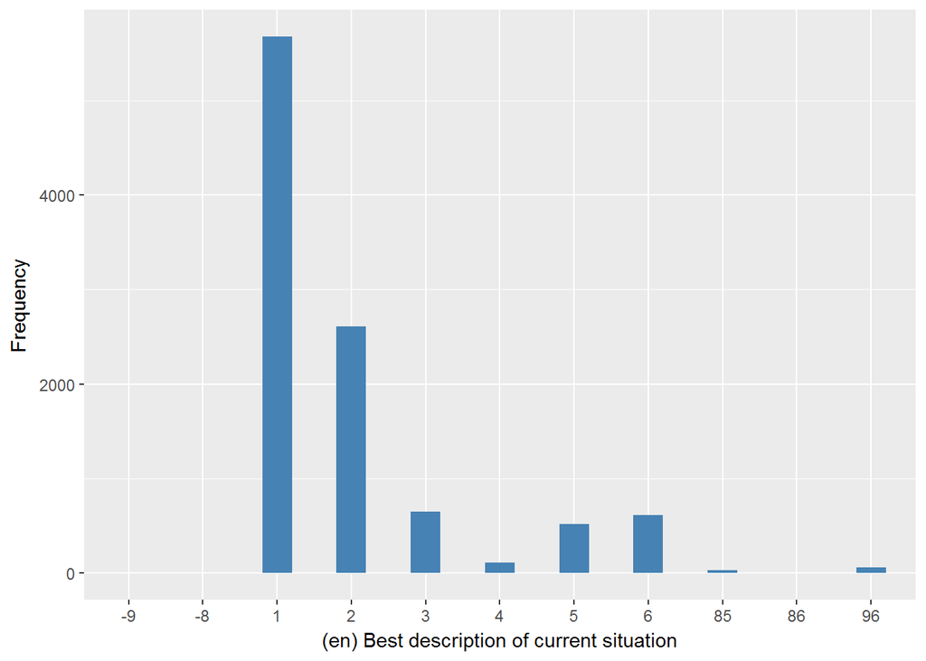

wprage

| Sample size | Missing values |
| --- | --- |
| 10274 | 9095 |

Summary

| Min. | 1st Qu. | Median | Mean | 3rd Qu. | Max. |
| --- | --- | --- | --- | --- | --- |
| 18 | 58 | 60 | 59.29 | 64 | 80 |

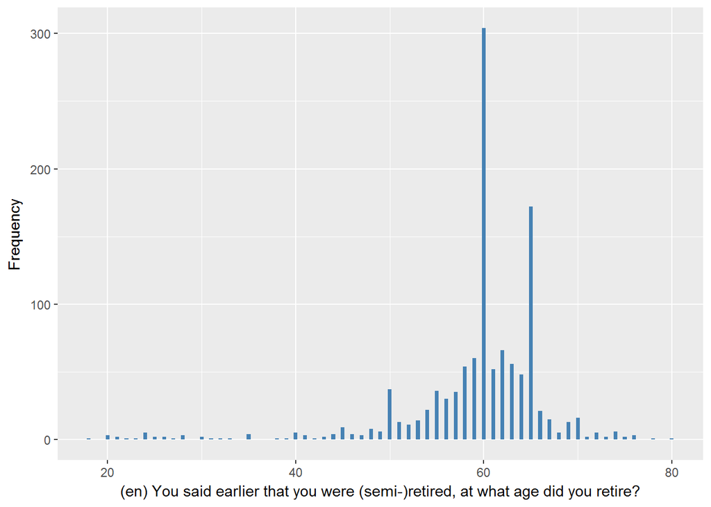

#### 2.1.5.2 Harmonisation algorithm

To compute `retired` from the study-specific variable it has to be recoded as follows:

- `1,96 into 1`
- `2,3,4,5,6,85,86,95 into 0`
- `-1 into 996`
- `-2 into 996`
- `-8 into 998`
- `-9 into 997`

To compute `age_retired` from the study-specific variable it has to be recoded as follows:

- `if retired == 1, age_retired = wprage`
- `-1 into 996`
- `-2 into 996`
- `-8 into 998`
- `-9 into 997`
- `if retired == 0, age_retired = 996`

**R script:**

```r
# Categorical variable harmonization
ELSA_ds_w5 <- tibble(id = ELSA_w5$id)
ELSA_ds_w5$retired <- car::recode(ELSA_w5$wpdes, "c(1,96) = 1; c(2,3,4,5,6,85,86,95) = 0; -1 = 996; -2 = 996; -8 = 998; -9 = 997")

ELSA_w5 <- left_join(ELSA_w5, ELSA_ds, by = "id")

# Continuous variable harmonization
ELSA_ds_w5$age_retired <- car::recode(ELSA_w5$wprage, "c(-1,0) = 996; -2 = 996; -8 = 998; -9 = 997; NA = 999")
ELSA_ds_w5$age_retired[which(!is.na(ELSA_w5$age_retired) & !ELSA_w5$age_retired %in%
    miss_values_vector)] <- ELSA_w5$age_retired[which(!is.na(ELSA_w5$age_retired) &
    !ELSA_w5$age_retired %in% miss_values_vector)]
ELSA_ds_w5$age_retired[which(!ELSA_w5$wprage %in% c(-2, -1, 0, -8, -9))] <- ELSA_w5$wprage[which(!ELSA_w5$wprage %in%
    c(-2, -1, 0, -8, -9))]

# Update of global table
assign_merge <- function(endtib, sttib, log_vec = c(T), col_end_index = NULL,
    col_st_index = NULL) {
    newtib <- full_join(endtib, sttib, by = "id")
    row.names(newtib) <- newtib$id
    newtib[log_vec, col_end_index] <- newtib[log_vec, col_st_index]
    id_ind <- match("id", names(newtib))
    newtib <- newtib[, c(id_ind, col_end_index)]
    names(newtib)[2] <- "x"
    newtib$x <- car::recode(newtib$x, "NA=999")
    names(newtib)[2] <- names(endtib)[col_end_index]
    newtib
}
ELSA_ds_prov <- ELSA_ds[, c(1, 2)]
ELSA_ds_prov <- assign_merge(ELSA_ds_prov, ELSA_ds_w5, log_vec = ELSA_ds_w5$id,
    col_end_index = 2, col_st_index = 3)
ELSA_ds_aux <- ELSA_ds[, c(1, 3)]
ELSA_ds_aux <- assign_merge(ELSA_ds_aux, ELSA_ds_w5, log_vec = ELSA_ds_w5$id[which(ELSA_ds_w5$retired !=
    999)], col_end_index = 2, col_st_index = 4)
ELSA_ds <- ELSA_ds_prov
ELSA_ds$age_retired <- ELSA_ds_aux$age_retired
rm(ELSA_ds_prov)
rm(ELSA_ds_aux)
```

#### 2.1.5.3 Statistics of the new harmonized variable

Participant is currently retired

| Sample size | Missing values |
| --- | --- |
| 10274 | 8 |

Category

|  | 0 | 1 |
| --- | --- | --- |
| Frequency | 4533.00 | 5733.0 |
| Percentage | 44.12 | 55.8 |

Type of missing

|  | 991 | 992 | 993 | 994 | 995 | 996 | 997 | 998 | 999 | NA |
| --- | --- | --- | --- | --- | --- | --- | --- | --- | --- | --- |
| Frequency | 0 | 0 | 0 | 0 | 0 | 0 | 4.00 | 4.00 | 0 | 0 |
| Percentage | 0 | 0 | 0 | 0 | 0 | 0 | 0.04 | 0.04 | 0 | 0 |

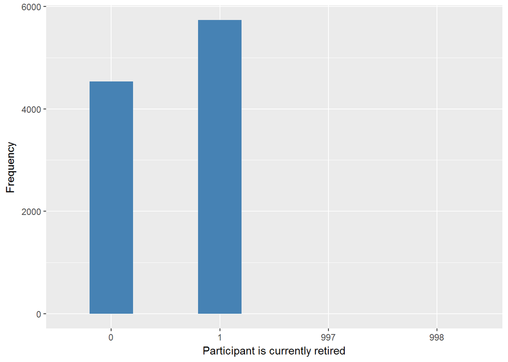

Age (in years) at which participant retired

| Sample size | Missing values |
| --- | --- |
| 10274 | 4022 |

Values

|  | No-missings | 991 | 992 | 993 | 994 | 995 | 996 | 997 | 998 | 999 | NA |
| --- | --- | --- | --- | --- | --- | --- | --- | --- | --- | --- | --- |
| Frequency | 6252.00 | 0 | 0 | 0 | 0 | 0 | 4005.00 | 1.00 | 16.00 | 0 | 0 |
| Percentage | 60.85 | 0 | 0 | 0 | 0 | 0 | 38.98 | 0.01 | 0.16 | 0 | 0 |

Summary

| Min. | 1st Qu. | Median | Mean | 3rd Qu. | Max. |
| --- | --- | --- | --- | --- | --- |
| 18 | 56 | 60 | 58.73 | 63 | 81 |

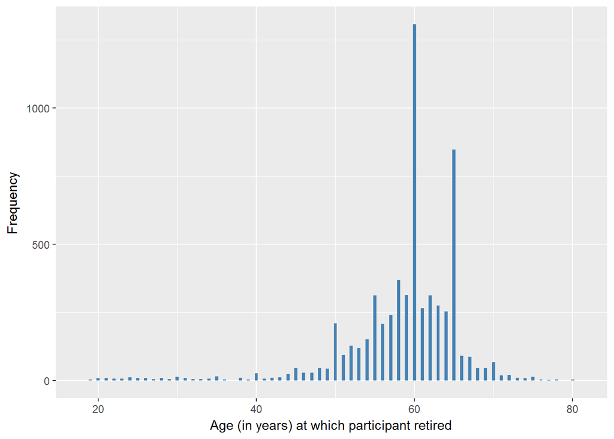

#### 2.1.5.4 Validation

### 2.1.6 Wave 6

#### 2.1.6.1 Study-specific variable description

| **Name** | `WpDes` | `WpRAge` |
| --- | --- | --- |
| **Label** | `Best description of current situation` | `You said earlier that you were (semi)retired, at what age did you retire?` |
| **Table name** | `wave_6_elsa_data_v2` | `wave_6_elsa_data_v2` |
| **Categories** | `1 = Retired` `2 = Employed` `3 = Self-employed` `4 = Unemployed` `5 = Permanently sick or disabled` `6 = Looking after home or family` `85 = Other answer` `86 = Irrelevant response` `95 = Other (SPEC… | `continuous` |
| **Missings** | `-1 = Not applicable` `-2 = Schedule not applicable` `-8 = Don't Know` `-9 = Refusal` | `-1 = Not applicable` `-2 = Schedule not applicable` `-8 = Don't Know` `-9 = Refusal` |
| **Description** |  |  |

WpDes

| Sample size | Missing values |
| --- | --- |
| 10601 | 2 |

Category

|  | 1 | 2 | 3 | 4 | 5 | 6 | 85 | 96 |
| --- | --- | --- | --- | --- | --- | --- | --- | --- |
| Frequency | 5898.00 | 2766.00 | 688.00 | 119.00 | 497.00 | 541.0 | 45.00 | 45.00 |
| Percentage | 55.64 | 26.09 | 6.49 | 1.12 | 4.69 | 5.1 | 0.42 | 0.42 |

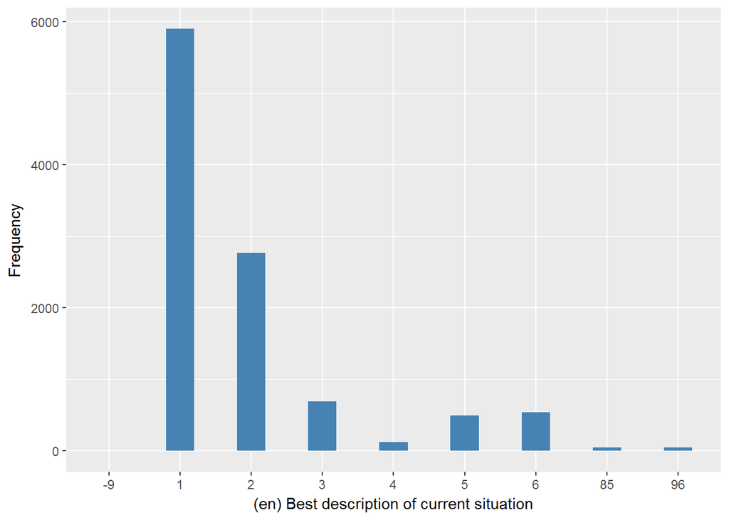

WpRAge

| Sample size | Missing values |
| --- | --- |
| 10601 | 9285 |

Summary

| Min. | 1st Qu. | Median | Mean | 3rd Qu. | Max. |
| --- | --- | --- | --- | --- | --- |
| 16 | 58 | 60 | 59.77 | 65 | 80 |

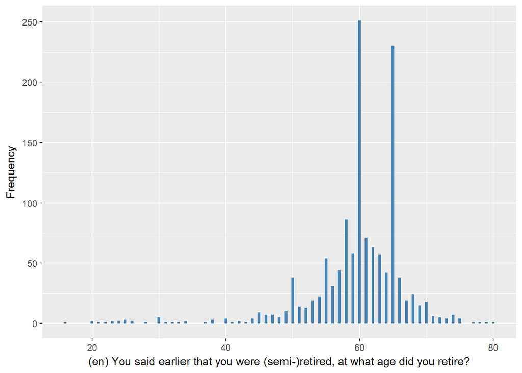

#### 2.1.6.2 Harmonisation algorithm

To compute `retired` from the study-specific variable it has to be recoded as follows:

- `1,96 into 1`
- `2,3,4,5,6,85,86,95 into 0`
- `-1 into 996`
- `-2 into 996`
- `-8 into 998`
- `-9 into 997`

To compute `age_retired` from the study-specific variable it has to be recoded as follows:

- `if retired == 1, age_retired = WpRAge`
- `-1 into 996`
- `-2 into 996`
- `-8 into 998`
- `-9 into 997`
- `if retired == 0, age_retired = 996`

**R script:**

```r
# Categorical variable harmonization
ELSA_ds_w6 <- tibble(id = ELSA_w6$id)
ELSA_ds_w6$retired <- car::recode(ELSA_w6$WpDes, "c(1,96) = 1; c(2,3,4,5,6,85,86,95) = 0; -1 = 996; -2 = 996; -8 = 998; -9 = 997")

ELSA_w6 <- left_join(ELSA_w6, ELSA_ds, by = "id")

# Continuous variable harmonization
ELSA_ds_w6$age_retired <- car::recode(ELSA_w6$WpRAge, "c(-1,0) = 996; -2 = 996; -8 = 998; -9 = 997; NA = 999")
ELSA_ds_w6$age_retired[which(!is.na(ELSA_w6$age_retired) & !ELSA_w6$age_retired %in%
    miss_values_vector)] <- ELSA_w6$age_retired[which(!is.na(ELSA_w6$age_retired) &
    !ELSA_w6$age_retired %in% miss_values_vector)]
ELSA_ds_w6$age_retired[which(!ELSA_w6$WpRAge %in% c(-2, -1, 0, -8, -9))] <- ELSA_w6$WpRAge[which(!ELSA_w6$WpRAge %in%
    c(-2, -1, 0, -8, -9))]

# Update of global table
assign_merge <- function(endtib, sttib, log_vec = c(T), col_end_index = NULL,
    col_st_index = NULL) {
    newtib <- full_join(endtib, sttib, by = "id")
    row.names(newtib) <- newtib$id
    newtib[log_vec, col_end_index] <- newtib[log_vec, col_st_index]
    id_ind <- match("id", names(newtib))
    newtib <- newtib[, c(id_ind, col_end_index)]
    names(newtib)[2] <- "x"
    newtib$x <- car::recode(newtib$x, "NA=999")
    names(newtib)[2] <- names(endtib)[col_end_index]
    newtib
}
ELSA_ds_prov <- ELSA_ds[, c(1, 2)]
ELSA_ds_prov <- assign_merge(ELSA_ds_prov, ELSA_ds_w6, log_vec = ELSA_ds_w6$id,
    col_end_index = 2, col_st_index = 3)
ELSA_ds_aux <- ELSA_ds[, c(1, 3)]
ELSA_ds_aux <- assign_merge(ELSA_ds_aux, ELSA_ds_w6, log_vec = ELSA_ds_w6$id[which(ELSA_ds_w6$retired !=
    999)], col_end_index = 2, col_st_index = 4)
ELSA_ds <- ELSA_ds_prov
ELSA_ds$age_retired <- ELSA_ds_aux$age_retired
rm(ELSA_ds_prov)
rm(ELSA_ds_aux)
```

#### 2.1.6.3 Statistics of the new harmonized variable

Participant is currently retired

| Sample size | Missing values |
| --- | --- |
| 10601 | 2 |

Category

|  | 0 | 1 |
| --- | --- | --- |
| Frequency | 4656.00 | 5943.00 |
| Percentage | 43.92 | 56.06 |

Type of missing

|  | 991 | 992 | 993 | 994 | 995 | 996 | 997 | 998 | 999 | NA |
| --- | --- | --- | --- | --- | --- | --- | --- | --- | --- | --- |
| Frequency | 0 | 0 | 0 | 0 | 0 | 0 | 2.00 | 0 | 0 | 0 |
| Percentage | 0 | 0 | 0 | 0 | 0 | 0 | 0.02 | 0 | 0 | 0 |

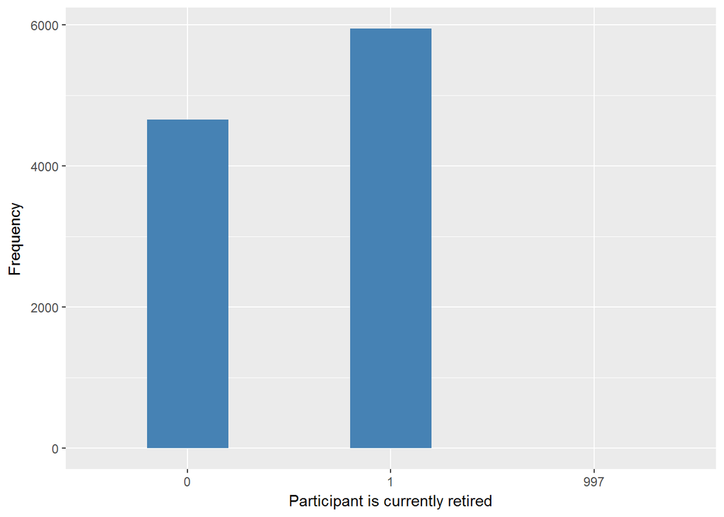

Age (in years) at which participant retired

| Sample size | Missing values |
| --- | --- |
| 10601 | 4184 |

Values

|  | No-missings | 991 | 992 | 993 | 994 | 995 | 996 | 997 | 998 | 999 | NA |
| --- | --- | --- | --- | --- | --- | --- | --- | --- | --- | --- | --- |
| Frequency | 6417.00 | 0 | 0 | 0 | 0 | 0 | 4167.00 | 0 | 17.00 | 0 | 0 |
| Percentage | 60.53 | 0 | 0 | 0 | 0 | 0 | 39.31 | 0 | 0.16 | 0 | 0 |

Summary

| Min. | 1st Qu. | Median | Mean | 3rd Qu. | Max. |
| --- | --- | --- | --- | --- | --- |
| 16 | 57 | 60 | 59.01 | 64 | 81 |

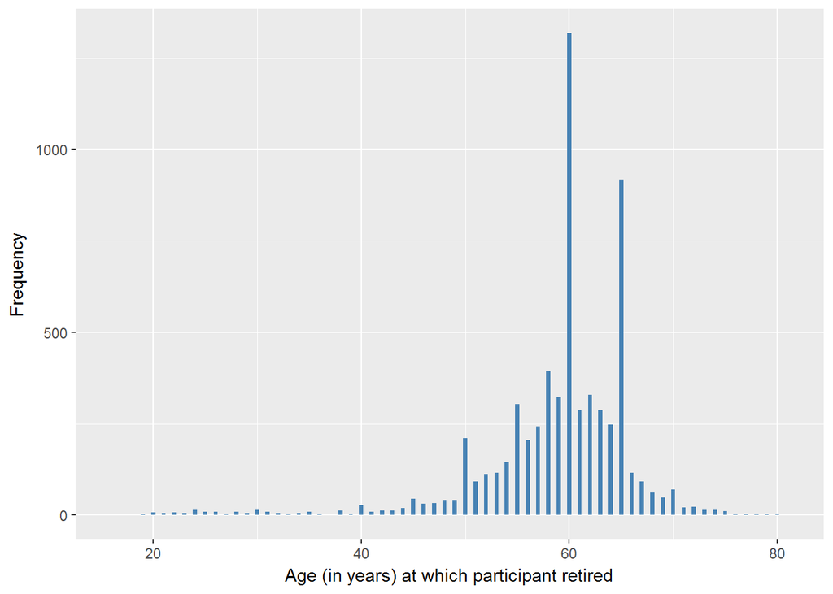

#### 2.1.6.4 Validation

### 2.1.7 Wave 7

| **Name** | `WpDes` | `WpRAge` |
| --- | --- | --- |
| **Label** | `Best description of current situation` | `You said earlier that you were (semi)retired, at what age did you retire?` |
| **Table name** | `wave_7_elsa_data` | `wave_7_elsa_data` |
| **Categories** | `1 = Retired` `2 = Employed` `3 = Self-employed` `4 = Unemployed` `5 = Permanently sick or disabled` `6 = Looking after home or family` `85 = Other answer` `86 = Irrelevant response` `95 = Other (SPEC… | `continuous` |
| **Missings** | `-1 = Not applicable` `-2 = Schedule not applicable` `-8 = Don't Know` `-9 = Refusal` | `-1 = Not applicable` `-2 = Schedule not applicable` `-8 = Don't Know` `-9 = Refusal` |
| **Description** |  |  |

WpDes

| Sample size | Missing values |
| --- | --- |
| 9666 | 0 |

Category

|  | 1 | 2 | 3 | 4 | 5 | 6 | 85 | 86 | 96 |
| --- | --- | --- | --- | --- | --- | --- | --- | --- | --- |
| Frequency | 5624.00 | 2387.00 | 639.00 | 92.00 | 370.00 | 482.00 | 37.00 | 1.00 | 34.00 |
| Percentage | 58.18 | 24.69 | 6.61 | 0.95 | 3.83 | 4.99 | 0.38 | 0.01 | 0.35 |

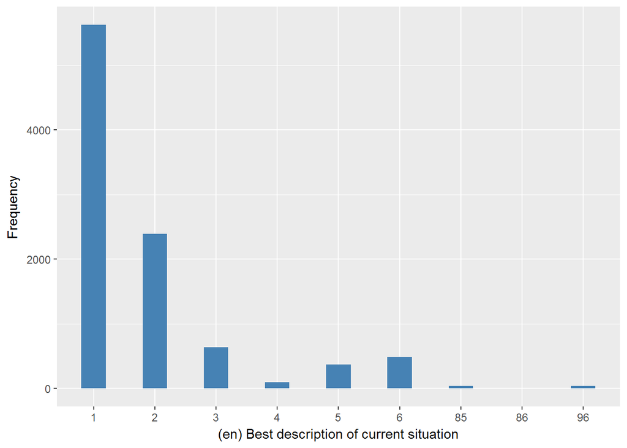

WpRAge

| Sample size | Missing values |
| --- | --- |
| 9666 | 8648 |

Summary

| Min. | 1st Qu. | Median | Mean | 3rd Qu. | Max. |
| --- | --- | --- | --- | --- | --- |
| 20 | 58 | 60 | 59.85 | 65 | 85 |

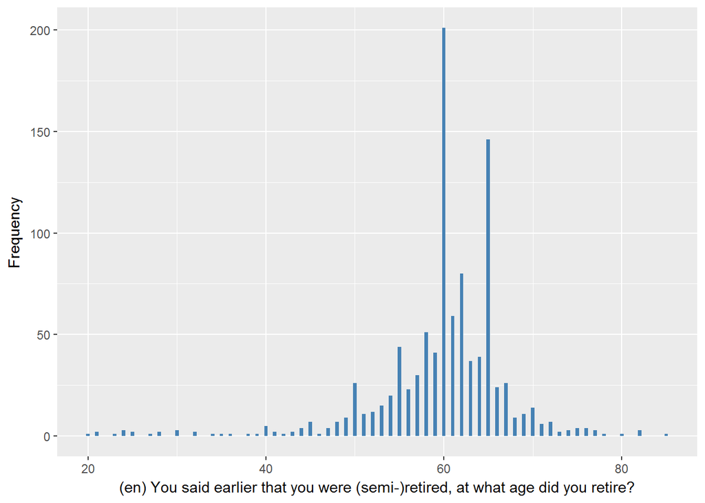

#### 2.1.7.1 Harmonisation algorithm

To compute `retired` from the study-specific variable it has to be recoded as follows:

- `1,96 into 1`
- `2,3,4,5,6,85,86,95 into 0`
- `-1 into 996`
- `-2 into 996`
- `-8 into 998`
- `-9 into 997`

To compute `age_retired` from the study-specific variable it has to be recoded as follows:

- `if retired == 1, age_retired = wprage`
- `-1 into 996`
- `-2 into 996`
- `-8 into 998`
- `-9 into 997`
- `if retired == 0, age_retired = 996`

**R script:**

```r
# Categorical variable harmonization
ELSA_ds_w7 <- tibble(id = ELSA_w7$id)
ELSA_ds_w7$retired <- car::recode(ELSA_w7$WpDes, "c(1,96) = 1; c(2,3,4,5,6,85,86,95) = 0; -1 = 996; -2 = 996; -8 = 998; -9 = 997")

ELSA_w7 <- left_join(ELSA_w7, ELSA_ds, by = "id")

# Continuous variable harmonization
ELSA_ds_w7$age_retired <- car::recode(ELSA_w7$WpRAge, "c(-1,0) = 996; -2 = 996; -8 = 998; -9 = 997; NA = 999")
ELSA_ds_w7$age_retired[which(!is.na(ELSA_w7$age_retired) & !ELSA_w7$age_retired %in%
    miss_values_vector)] <- ELSA_w7$age_retired[which(!is.na(ELSA_w7$age_retired) &
    !ELSA_w7$age_retired %in% miss_values_vector)]
ELSA_ds_w7$age_retired[which(!ELSA_w7$WpRAge %in% c(-2, -1, 0, -8, -9))] <- ELSA_w7$WpRAge[which(!ELSA_w7$WpRAge %in%
    c(-2, -1, 0, -8, -9))]

# Update of global table
rm(ELSA_ds)
```

#### 2.1.7.2 Statistics of the new harmonized variable

Participant is currently retired

| Sample size | Missing values |
| --- | --- |
| 9666 | 0 |

Category

|  | 0 | 1 |
| --- | --- | --- |
| Frequency | 4008.00 | 5658.00 |
| Percentage | 41.46 | 58.54 |

Type of missing

|  | 991 | 992 | 993 | 994 | 995 | 996 | 997 | 998 | 999 | NA |
| --- | --- | --- | --- | --- | --- | --- | --- | --- | --- | --- |
| Frequency | 0 | 0 | 0 | 0 | 0 | 0 | 0 | 0 | 0 | 0 |
| Percentage | 0 | 0 | 0 | 0 | 0 | 0 | 0 | 0 | 0 | 0 |

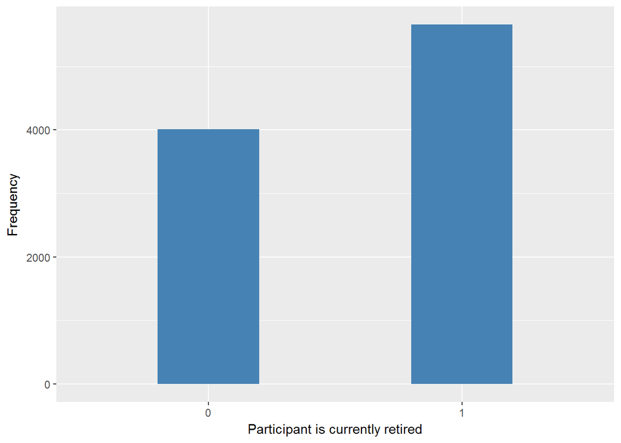

Age (in years) at which participant retired

| Sample size | Missing values |
| --- | --- |
| 9666 | 3541 |

Values

|  | No-missings | 991 | 992 | 993 | 994 | 995 | 996 | 997 | 998 | 999 | NA |
| --- | --- | --- | --- | --- | --- | --- | --- | --- | --- | --- | --- |
| Frequency | 6125.00 | 0 | 0 | 0 | 0 | 0 | 3522.00 | 1.00 | 18.00 | 0 | 0 |
| Percentage | 63.37 | 0 | 0 | 0 | 0 | 0 | 36.44 | 0.01 | 0.19 | 0 | 0 |

Summary

| Min. | 1st Qu. | Median | Mean | 3rd Qu. | Max. |
| --- | --- | --- | --- | --- | --- |
| 16 | 57 | 60 | 59.17 | 64 | 85 |

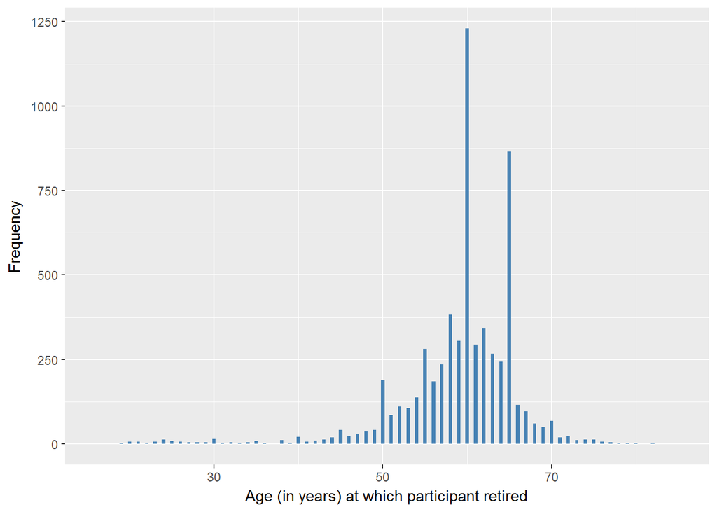

#### 2.1.7.3 Validation

## 2.2 Summary of descriptive statistics of the harmonised variable accross populations and waves

Two tables are generated:

1. Percentages of categories in each harmonised variable.
2. Frequencies and percentages of individuals with different trajectories. To avoid too large table, Only trajectories with percentages larger than 0.3 are shown.

```r
l.hds <- list(w1 = ELSA_ds_w1, w2 = ELSA_ds_w2, w3 = ELSA_ds_w3, w4 = ELSA_ds_w4,
    w5 = ELSA_ds_w5, w6 = ELSA_ds_w6, w7 = ELSA_ds_w7)

for (name in names(l.hds)) {
    aux_object <- l.hds[[name]]
    label(l.hds[[name]][[2]]) <- label(aux_object[[2]]) <- ds_label  # Text value assigned at the DS description, at the top
    l.hds[[name]][[2]] <- labelled(l.hds[[name]][[2]], labels = cat_label)
    label(l.hds[[name]][[3]]) <- label(aux_object[[3]]) <- ds_label_age  # Text value assigned at the DS description, at the top
    l.hds[[name]][[3]] <- labelled(l.hds[[name]][[3]], labels = cont_label)
    aux_object[[2]] <- car::recode(aux_object[[2]], "miss_values_vector=NA")
    aux_object[[2]] <- labelled(aux_object[[2]], labels = cat_label[1:2])
    m_name <- paste0("ELSA_m_ds_", name)
    assign(m_name, aux_object)
    rm(aux_object)
}

t.hds <- frq(l.hds[[1]][2])[[1]][, c(1, 2)]
for (i in seq_along(l.hds)) {
    t.hds[2 + i] <- frq(l.hds[[i]][2])[[1]][, 4]
}
t.hds[13, ] <- c("n", "sample size", sapply(l.hds, function(wave) length(wave[[1]])))
names(t.hds) <- c("val", "label", names(l.hds))
kable(t.hds)
```

| val | label | w1 | w2 | w3 | w4 | w5 | w6 | w7 |
| --- | --- | --- | --- | --- | --- | --- | --- | --- |
| 0 | No | 52.04 | 48.83 | 52.71 | 49.18 | 44.12 | 43.92 | 41.46 |
| 1 | Yes | 47.88 | 51.15 | 47.25 | 50.71 | 55.8 | 56.06 | 58.54 |
| 991 | CAPI interviewer error | 0 | 0 | 0 | 0 | 0 | 0 | 0 |
| 992 | Impute | 0 | 0 | 0 | 0 | 0 | 0 | 0 |
| 993 | Disable to measure | 0 | 0 | 0 | 0 | 0 | 0 | 0 |
| 994 | Not attempt not done | 0 | 0 | 0 | 0 | 0 | 0 | 0 |
| 995 | Does not answer | 0 | 0 | 0 | 0 | 0 | 0 | 0 |
| 996 | Not applicable | 0 | 0 | 0 | 0 | 0 | 0 | 0 |
| 997 | Refuse | 0.03 | 0.01 | 0.02 | 0.07 | 0.04 | 0.02 | 0 |
| 998 | Do not know | 0.05 | 0.01 | 0.02 | 0.04 | 0.04 | 0 | 0 |
| 999 | Missing | 0 | 0 | 0 | 0 | 0 | 0 | 0 |
| NA | NA | 0 | 0 | 0 | 0 | 0 | 0 | 0 |
| n | sample size | 12099 | 9432 | 9771 | 11050 | 10274 | 10601 | 9666 |

```r
dbb <- get(paste0("ELSA_m_ds_", names(l.hds)[1]))[, c("id", "retired")]
for (ind in 2:length(l.hds)) {
    dbb <- merge(dbb, get(paste0("ELSA_m_ds_", names(l.hds)[ind]))[, c("id",
        "retired")], by = "id", suffixes = c("", paste0(".", names(l.hds)[ind])),
        all = T)
}
names(dbb) <- c("id", names(l.hds))

v.dbb <- dbb[, 2]
for (ind in 2:length(l.hds)) {
    v.dbb <- paste0(v.dbb, dbb[, ind + 1])
}
f.dbb <- frq(v.dbb)[[1]][, c(1, 2, 4)]
kable(f.dbb[f.dbb[, 3] >= 0.3, ])
```

|  | val | frq | raw.prc |
| --- | --- | --- | --- |
| 1 | 0000000 | 590 | 3.19 |
| 2 | 0000001 | 237 | 1.28 |
| 3 | 000000NA | 81 | 0.44 |
| 5 | 0000011 | 293 | 1.58 |
| 9 | 00000NANA | 72 | 0.39 |
| 14 | 0000111 | 277 | 1.50 |
| 26 | 0000NANANA | 95 | 0.51 |
| 38 | 0001111 | 253 | 1.37 |
| 69 | 000NANANANA | 267 | 1.44 |
| 96 | 0011111 | 217 | 1.17 |
| 112 | 001NANANANA | 66 | 0.36 |
| 162 | 00NANANANANA | 463 | 2.50 |
| 223 | 0111111 | 300 | 1.62 |
| 242 | 011NANANANA | 75 | 0.41 |
| 262 | 01NANANANANA | 128 | 0.69 |
| 364 | 0NANANANANANA | 961 | 5.20 |
| 428 | 1011111 | 101 | 0.55 |
| 460 | 10NANANANANA | 102 | 0.55 |
| 483 | 1101111 | 68 | 0.37 |
| 525 | 1111111 | 1247 | 6.74 |
| 526 | 111111NA | 285 | 1.54 |
| 529 | 11111NANA | 220 | 1.19 |
| 534 | 1111NANANA | 303 | 1.64 |
| 547 | 111NANANANA | 431 | 2.33 |
| 573 | 11NANANANANA | 596 | 3.22 |
| 634 | 1NANANANANANA | 1120 | 6.06 |
| 680 | NANA00000 | 655 | 3.54 |
| 681 | NANA00001 | 79 | 0.43 |
| 682 | NANA0000NA | 93 | 0.50 |
| 688 | NANA000NANA | 75 | 0.41 |
| 701 | NANA00NANANA | 108 | 0.58 |
| 733 | NANA0NANANANA | 293 | 1.58 |
| 759 | NANANA0000 | 577 | 3.12 |
| 760 | NANANA0001 | 129 | 0.70 |
| 761 | NANANA000NA | 104 | 0.56 |
| 763 | NANANA0011 | 128 | 0.69 |
| 767 | NANANA00NANA | 97 | 0.52 |
| 772 | NANANA0111 | 126 | 0.68 |
| 785 | NANANA0NANANA | 208 | 1.12 |
| 799 | NANANA1111 | 578 | 3.13 |
| 800 | NANANA111NA | 102 | 0.55 |
| 802 | NANANA11NANA | 67 | 0.36 |
| 810 | NANANA1NANANA | 154 | 0.83 |
| 827 | NANANANANA00 | 832 | 4.50 |
| 829 | NANANANANA0NA | 248 | 1.34 |
| 831 | NANANANANA11 | 61 | 0.33 |
| 833 | NANANANANANA0 | 471 | 2.55 |

# 3 Quality estimation

The harmonization algorithm is essentially that of g2aging. This means that:

- Semi-retired is coded as retired;
- The orden of priority for the age of retired is: first, the age answered at each wave; second, the last age answered at previous waves; third, the missing values. As a consequence, one individual can have different harmonized ages of retirement across waves.

```r
ELSA_ds_join <- full_join(ELSA_ds_w1, ELSA_ds_w2, by = "id", suffix = c("_w1",
    ""))
ELSA_ds_join <- full_join(ELSA_ds_join, ELSA_ds_w3, by = "id", suffix = c("_w2",
    ""))
ELSA_ds_join <- full_join(ELSA_ds_join, ELSA_ds_w4, by = "id", suffix = c("_w3",
    ""))
ELSA_ds_join <- full_join(ELSA_ds_join, ELSA_ds_w5, by = "id", suffix = c("_w4",
    ""))
ELSA_ds_join <- full_join(ELSA_ds_join, ELSA_ds_w6, by = "id", suffix = c("_w5",
    ""))
ELSA_ds_join <- full_join(ELSA_ds_join, ELSA_ds_w7, by = "id", suffix = c("_w6",
    "_w7"))

len_ELSA <- length(ELSA_ds_join$id)

# We save in a list with all the individuals, the variances corresponding to
# the answered years.

age_columns <- c("age_retired_w1", "age_retired_w2", "age_retired_w3", "age_retired_w4",
    "age_retired_w5", "age_retired_w6", "age_retired_w7")

nnvar <- function(x) {
    partv <- as.numeric(ELSA_ds_join[x, age_columns])
    partv <- partv[!is.na(partv)]
    partvv <- partv[!partv %in% miss_values_vector]
    if (length(partvv) != 0) {
        partv <- partvv
    }
    return(var(partv))
}
ntvar <- lapply(1:len_ELSA, nnvar)

# The next vector keeps the quantity of non-missing data for each individual
nonmiss <- Reduce("+", lapply(ELSA_ds_join[age_columns], function(x) !x %in%
    miss_values_vector & !is.na(x)))

ntvar <- unlist(ntvar)
nttib <- tibble(id = ELSA_ds_join$id, varz = ntvar)
ELSA_ds_join <- full_join(ELSA_ds_join, nttib, by = "id")

kable(ELSA_ds_join[which(ntvar != 0 & nonmiss >= 2), c("id", age_columns, "varz")],
    align = "c", caption = "Individuals which answered more than one non-missing (excluding also 0) age")
```

Individuals which answered more than one non-missing (excluding also 0) age

| id | age_retired_w1 | age_retired_w2 | age_retired_w3 | age_retired_w4 | age_retired_w5 | age_retired_w6 | age_retired_w7 | varz |
| --- | --- | --- | --- | --- | --- | --- | --- | --- |
| 100047 | 996 | 996 | 65 | 65 | 65 | NA | 64 | 0.2500000 |
| 100098 | 996 | 996 | 65 | 65 | 76 | 76 | 76 | 36.3000000 |
| 103729 | 996 | 996 | 996 | 61 | 61 | 61 | 62 | 0.2500000 |
| 103786 | 58 | 58 | NA | 58 | 60 | NA | 60 | 1.2000000 |
| 103787 | 32 | 32 | 32 | 32 | 60 | 60 | 60 | 224.0000000 |
| 103797 | 63 | 63 | 63 | 63 | 63 | NA | 60 | 1.5000000 |
| 103812 | 53 | 53 | 53 | 53 | 50 | 50 | 50 | 2.5714286 |
| 103829 | 996 | 996 | 996 | 34 | 34 | 34 | 35 | 0.2500000 |
| 103844 | 996 | 996 | 996 | 48 | 48 | NA | 55 | 16.3333333 |
| 103874 | 996 | 996 | 996 | 60 | 60 | 60 | 65 | 6.2500000 |
| 103891 | 996 | 48 | 48 | NA | 48 | 48 | 65 | 57.8000000 |
| 103968 | 996 | 73 | 73 | 73 | 73 | 60 | 60 | 45.0666667 |
| 103972 | 996 | 996 | NA | 65 | NA | 66 | 66 | 0.3333333 |
| 103983 | 60 | 60 | 60 | 60 | 27 | 27 | 27 | 311.1428571 |
| 103993 | 996 | 996 | 60 | 60 | 60 | 60 | 21 | 304.2000000 |
| 104029 | 996 | 58 | 58 | 58 | 63 | 63 | 60 | 6.0000000 |
| 104051 | 62 | 62 | 62 | NA | NA | 65 | NA | 2.2500000 |
| 104057 | 996 | NA | NA | 996 | 66 | 66 | 60 | 12.0000000 |
| 104061 | 57 | NA | NA | 57 | 57 | NA | 66 | 20.2500000 |
| 104087 | 62 | 62 | 62 | 62 | 62 | NA | 63 | 0.1666667 |
| 104089 | 996 | 50 | 50 | 50 | NA | NA | 52 | 1.0000000 |
| 104113 | 996 | 996 | 59 | 59 | 59 | 65 | NA | 9.0000000 |
| 104119 | 65 | 65 | 65 | 65 | 74 | 74 | 74 | 23.1428571 |
| 104128 | 49 | 49 | 49 | 49 | 49 | 47 | 47 | 0.9523810 |
| 104147 | 48 | 48 | NA | 48 | NA | 60 | 60 | 43.2000000 |
| 104178 | 996 | NA | NA | NA | 63 | 63 | 66 | 3.0000000 |
| 104202 | 996 | NA | 996 | 996 | 60 | 60 | 55 | 8.3333333 |
| 104246 | 60 | 60 | 60 | 60 | 60 | 58 | 58 | 0.9523810 |
| 104262 | 52 | 52 | 52 | 52 | 60 | 60 | 60 | 18.2857143 |
| 104293 | 65 | 65 | 65 | 65 | 65 | 59 | 59 | 8.5714286 |

[output cut: 626 more lines]